# Analyses of GSE138988; GSE119977 and GSE173953

## Matrices

Good! Now we can proceed by designing our matrices.

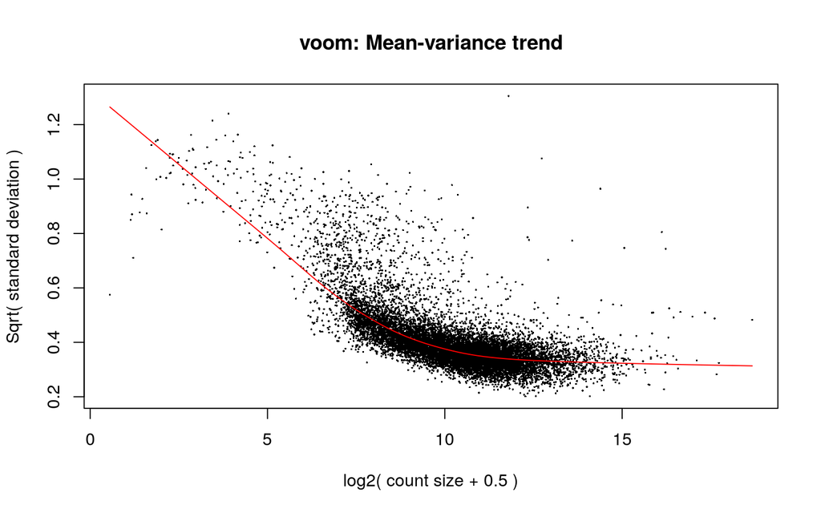

```r
#Preparing the metadata I will use
#This is the name of the samples
Sample_names <- c("PE.WTCT", "PE.WTCT", "PE.WTCT", "PE.WTAR", "PE.WTAR", "PE.WTAR", "SE.WTAR", "SE.WTAR", "SE.WTAR", "SE.KOAR", "SE.KOAR", "SE.KOAR", "WTAR", "WTAR", "WTAR", "WTSO", "WTSO", "WTSO", "KOSO", "KOSO", "GFUN", "GFUN", "GFUN", "KOUN", "KOUN", "KOUN", "GFSO", "GFSO", "GFSO", rep("WT.U2.CT",2), rep("WT.U2.DS6",2), rep("KO.U2.CT",2),rep("KO.U2.DS4",2), rep("WT.A5.CT",2), rep("WT.A5.DS4",2), rep("KO.A5.CT",2), rep("KO.A5.DS4",2), rep("KO.U2.DS6",3), rep("KO.U2.DS24",3))

Cells <- c("U2-OS", "U2-OS", "U2-OS", "U2-OS", "U2-OS", "U2-OS", "U2-OS", "U2-OS", "U2-OS", "U2-OS", "U2-OS", "U2-OS", "U2-OS", "U2-OS", "U2-OS", "U2-OS", "U2-OS", "U2-OS", "U2-OS", "U2-OS", "U2-OS", "U2-OS", "U2-OS", "U2-OS", "U2-OS", "U2-OS", "U2-OS", "U2-OS", "U2-OS", rep("U2-OS",2), rep("U2-OS",2), rep("U2-OS",2),rep("U2-OS",2), rep("A524",2), rep("A524",2), rep("A524",2), rep("A524",2), rep("U2-OS",3), rep("U2-OS",3))

#"Complex" stress
#StressStat <- c("CT", "CT", "CT", "AR", "AR", "AR", "AR", "AR", "AR", "AR", "AR", "AR", "AR", "AR", "AR", "SO", "SO", "SO", "SO", "SO", "CT", "CT", "CT", "CT", "CT", "CT", "SO", "SO", "SO", rep("CT",2), rep("DS6",2), rep("CT",2),rep("DS4",2), rep("CT",2), rep("DS4",2), rep("CT",2), rep("DS4",2), rep("DS6",3), rep("DS24",3))

#Simplified Stress
StressStat <- c("CT", "CT", "CT", "AR", "AR", "AR", "AR", "AR", "AR", "AR", "AR", "AR", "AR", "AR", "AR", "SO", "SO", "SO", "SO", "SO", "CT", "CT", "CT", "CT", "CT", "CT", "SO", "SO", "SO", rep("CT",2), rep("DS",2), rep("CT",2),rep("DS",2), rep("CT",2), rep("DS",2), rep("CT",2), rep("DS",2), rep("DS",3), rep("DS",3))

G3Status <- c("WT", "WT", "WT", "WT", "WT", "WT", "WT", "WT", "WT", "KO", "KO", "KO", "WT", "WT", "WT", "WT", "WT", "WT", "KO", "KO", "GF", "GF", "GF", "KO", "KO", "KO", "GF", "GF", "GF", rep("WT",2), rep("WT",2), rep("KO",2),rep("KO",2), rep("WT",2), rep("WT",2), rep("KO",2), rep("KO",2), rep("KO",3), rep("KO",3))

StudyNum <-c(rep("Study1", 6), rep("Study2",6), rep("Study3", 17), rep("Study4",8),rep("Study5",8),rep("Study6",6))


SGStatus <- c("NO", "NO", "NO", "YES", "YES", "YES", "YES", "YES", "YES", "NO", "NO", "NO", "YES", "YES", "YES", "YES", "YES", "YES", "YES", "YES", "NO", "NO", "NO", "NO", "NO", "NO", "YES", "YES", "YES", rep("NO",2), rep("YES",2), rep("NO",2),rep("NO",2), rep("NO",2), rep("YES",2), rep("NO",2), rep("NO",2), rep("NO",3), rep("NO",3))

metadata <- data.frame(Cell=Cells, Stress=StressStat, G3=G3Status, Study=StudyNum, SG=SGStatus)



#To be able to use Voom, we must first convert our read count table into a special DGE object.
D0 <- DGEList(finaltable)


#Then we calculate the normalisation factors for these new generated data frames
#Bear in mind this step calculates the normalisation factors, but does not normalise itself.
D0 <- calcNormFactors(D0)

mm <- model.matrix(~0+Sample_names)

#and now we normalize. This step also turns our counts into log2-counts per million.
y <- voom(D0, mm, plot = T)
```

## Normalisation

For normalisation I convert the read counts into log2CPMs. Its a good way to visualise how the reads are.

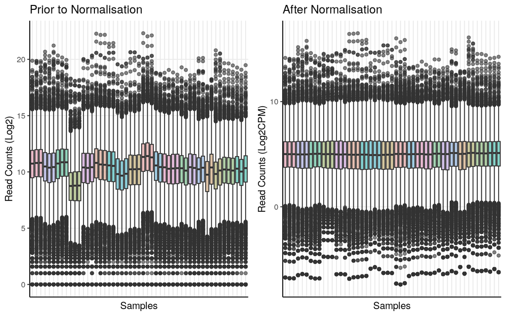

```r
#To visualise how the normalisation went.

custom_palette <- qualitative_hcl(20, palette = "Dynamic")
custom_palette <- sample(custom_palette,20)

dfforboxy <- finaltable

orderforplots <- Sample_names
colouring <- data.frame(Sample=colnames(dfforboxy), Types=orderforplots)
dfforboxy <- reshape2::melt(dfforboxy)
colnames(dfforboxy) <- c("Sample", "Expression")
dfforboxy <- merge(dfforboxy, colouring, by="Sample")
prenorm <- ggplot(dfforboxy, aes(x=Sample, y=(log2(Expression+1)), fill=Types)) + geom_boxplot(alpha=0.6) + theme_bw() + ylab("Read Counts (Log2)") + xlab("Samples") + scale_fill_manual(name = "Sample Type", values = custom_palette, labels=unique(Sample_names), breaks =unique(Sample_names)) +
  theme(axis.line = element_line(colour = "black"),
        panel.grid.minor = element_blank(),
        panel.border = element_blank(),
        panel.background = element_blank(),
        axis.text.x=element_blank(),
        axis.ticks.x=element_blank(),
        legend.position = "None") + ggtitle("Prior to Normalisation")

dfforboxy <- y$E
dfforboxy <- reshape2::melt(dfforboxy)
dfforboxy <- dfforboxy[,-1]
colnames(dfforboxy) <- c("Sample", "Expression")
dfforboxy <- merge(dfforboxy, colouring, by="Sample")
postnorm <- ggplot(dfforboxy, aes(x=Sample, y=Expression, fill=Types)) + geom_boxplot(alpha=0.6) + theme_bw() + ylab("Read Counts (Log2CPM)") + xlab("Samples") + scale_fill_manual(name = "Sample Type", values = custom_palette, labels=unique(Sample_names), breaks =unique(Sample_names)) +
  theme(axis.line = element_line(colour = "black"),
        panel.grid.minor = element_blank(),
        panel.border = element_blank(),
        panel.background = element_blank(),
        axis.text.x=element_blank(),
        axis.ticks.x=element_blank(),
        legend.position = "None") + ggtitle("After Normalisation")

ggarrange(prenorm, postnorm, nrow=1)
```

## PCA

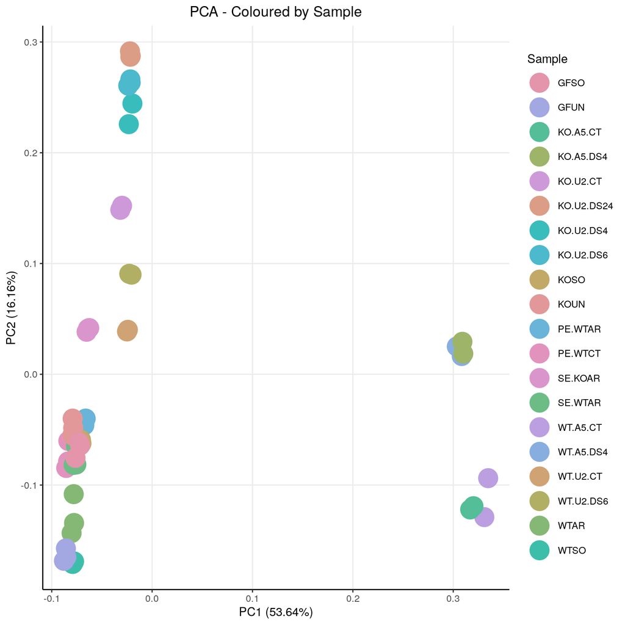

```r
#This prepares my data for the PCA
dfforpca <- y$E
dfforpca <- t(dfforpca)
dfforpca <- as.data.frame(dfforpca) # needs to be a data.frame
dfforpca <- apply(dfforpca, 2, as.numeric) # Ensure numeric
dfforpca <- as.data.frame(dfforpca) # still needs to be a data.frame

# Add metadata, which we will then use to plot
dfforpca$Sample <- Sample_names
dfforpca$StressType <- metadata$Stress
dfforpca$CellType <- metadata$Cell
dfforpca$SGPres <- metadata$SG
dfforpca$StudyNum <- metadata$Study
dfforpca$G3 <- metadata$G3

# PCA computation itself. I do one PCA for each variable I want to see.
pca_res <- prcomp(dfforpca[, 1:(ncol(dfforpca)-6)], scale = FALSE)
p_sample<- autoplot(pca_res, data = dfforpca, x = 1, y = 2, colour = "Sample", size = 8) +
  theme_bw() +
  scale_colour_manual(name = "Sample", values = custom_palette) +
  ggtitle("PCA - Coloured by Sample") +
  theme(plot.title = element_text(hjust = 0.5),
        axis.line = element_line(colour = "black"),
        panel.grid.minor = element_blank(),
        panel.border = element_blank(),
        panel.background = element_blank())

p_stress<- autoplot(pca_res, data = dfforpca, x = 1, y = 2, colour = "StressType", size = 8) +
  theme_bw() +
  scale_colour_manual(name = "StressType", values = custom_palette) +
  ggtitle("PCA - Coloured by StressType") +
  theme(plot.title = element_text(hjust = 0.5),
        axis.line = element_line(colour = "black"),
        panel.grid.minor = element_blank(),
        panel.border = element_blank(),
        panel.background = element_blank())

p_sg <- autoplot(pca_res, data = dfforpca, x = 1, y = 2, colour = "SGPres", size = 8) +
  theme_bw() +
  scale_colour_manual(name = "SGPres", values = custom_palette) +
  ggtitle("PCA - Coloured by SGPres") +
  theme(plot.title = element_text(hjust = 0.5),
        axis.line = element_line(colour = "black"),
        panel.grid.minor = element_blank(),
        panel.border = element_blank(),
        panel.background = element_blank())

p_cell <- autoplot(pca_res, data = dfforpca, x = 1, y = 2, colour = "CellType", size = 8) +
  theme_bw() +
  scale_colour_manual(name = "CellType", values = custom_palette) +
  ggtitle("PCA - Coloured by CellType") +
  theme(plot.title = element_text(hjust = 0.5),
        axis.line = element_line(colour = "black"),
        panel.grid.minor = element_blank(),
        panel.border = element_blank(),
        panel.background = element_blank())

p_study <- autoplot(pca_res, data = dfforpca, x = 1, y = 2, colour = "StudyNum", size = 8) +
  theme_bw() +
  scale_colour_manual(name = "StudyNum", values = custom_palette) +
  ggtitle("PCA - Coloured by StudyNum") +
  theme(plot.title = element_text(hjust = 0.5),
        axis.line = element_line(colour = "black"),
        panel.grid.minor = element_blank(),
        panel.border = element_blank(),
        panel.background = element_blank())

p_g3 <- autoplot(pca_res, data = dfforpca, x = 1, y = 2, colour = "G3", size = 8) +
  theme_bw() +
  scale_colour_manual(name = "G3", values = custom_palette) +
  ggtitle("PCA - Coloured by G3") +
  theme(plot.title = element_text(hjust = 0.5),
        axis.line = element_line(colour = "black"),
        panel.grid.minor = element_blank(),
        panel.border = element_blank(),
        panel.background = element_blank())

p_sample
```

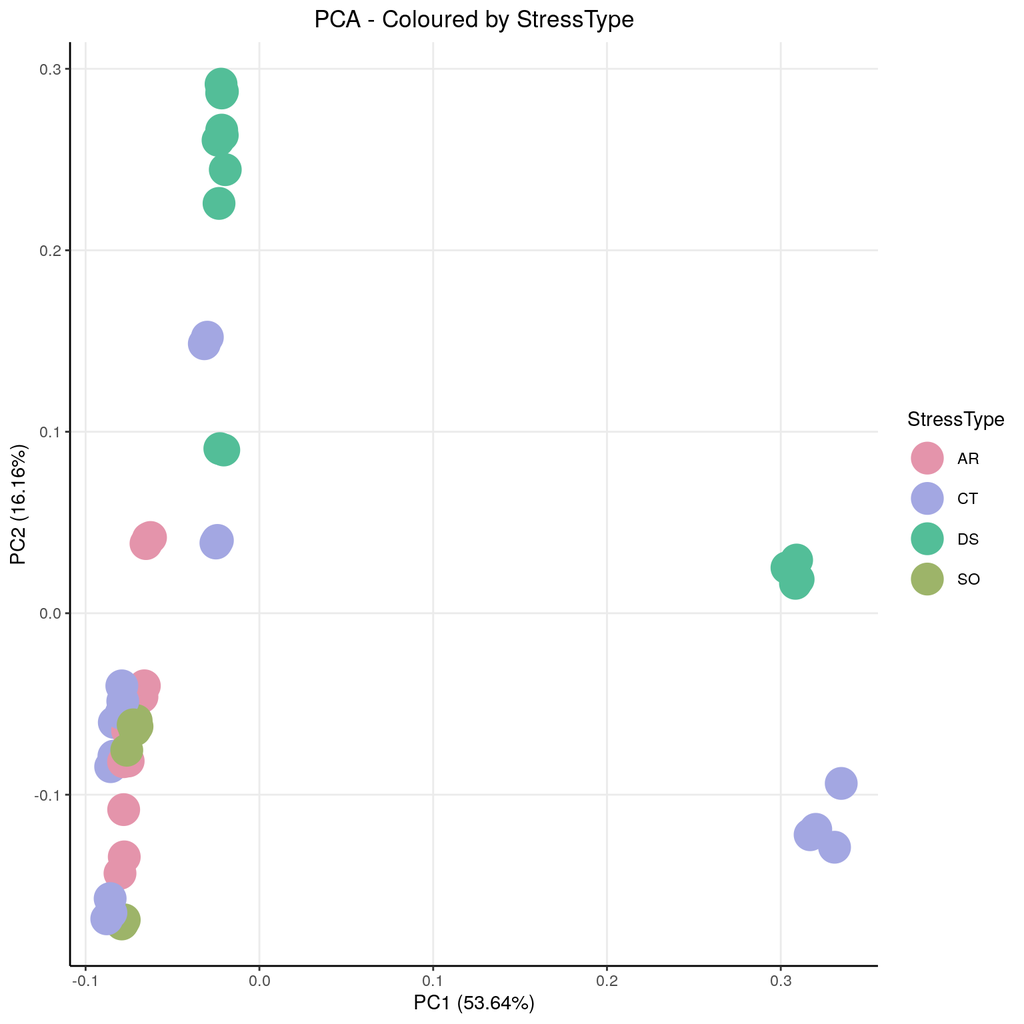

```r
p_stress
```

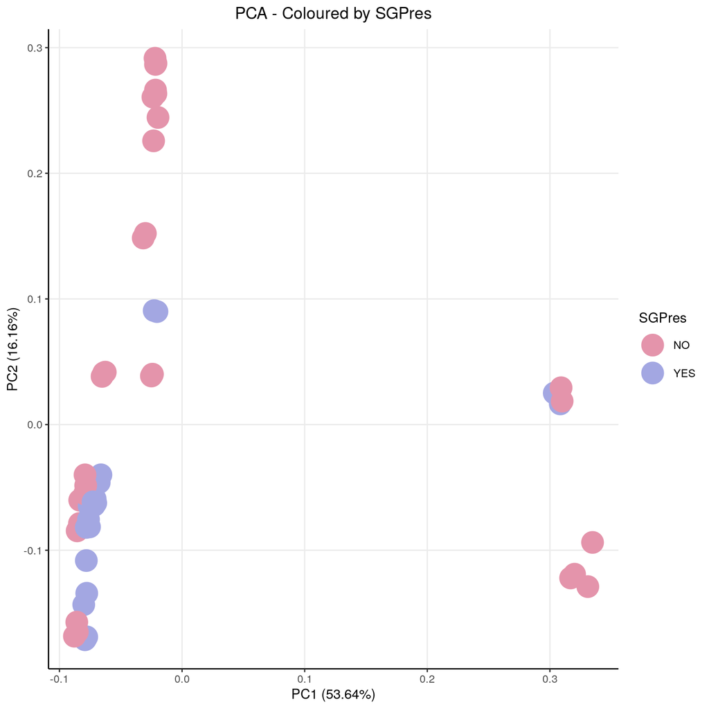

```r
p_sg
```

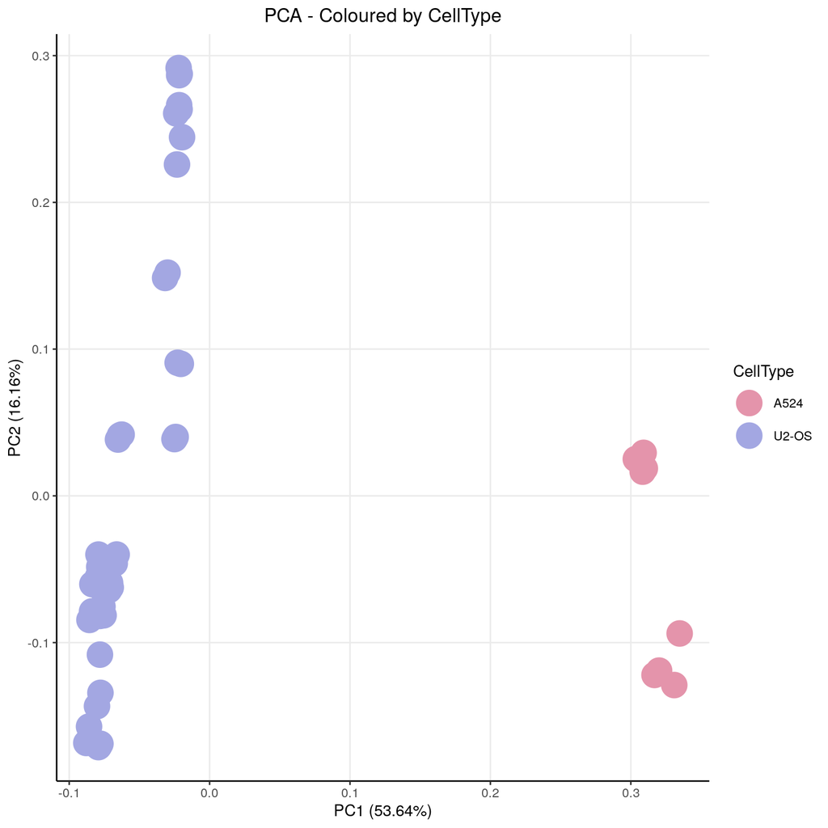

```r
p_cell
```

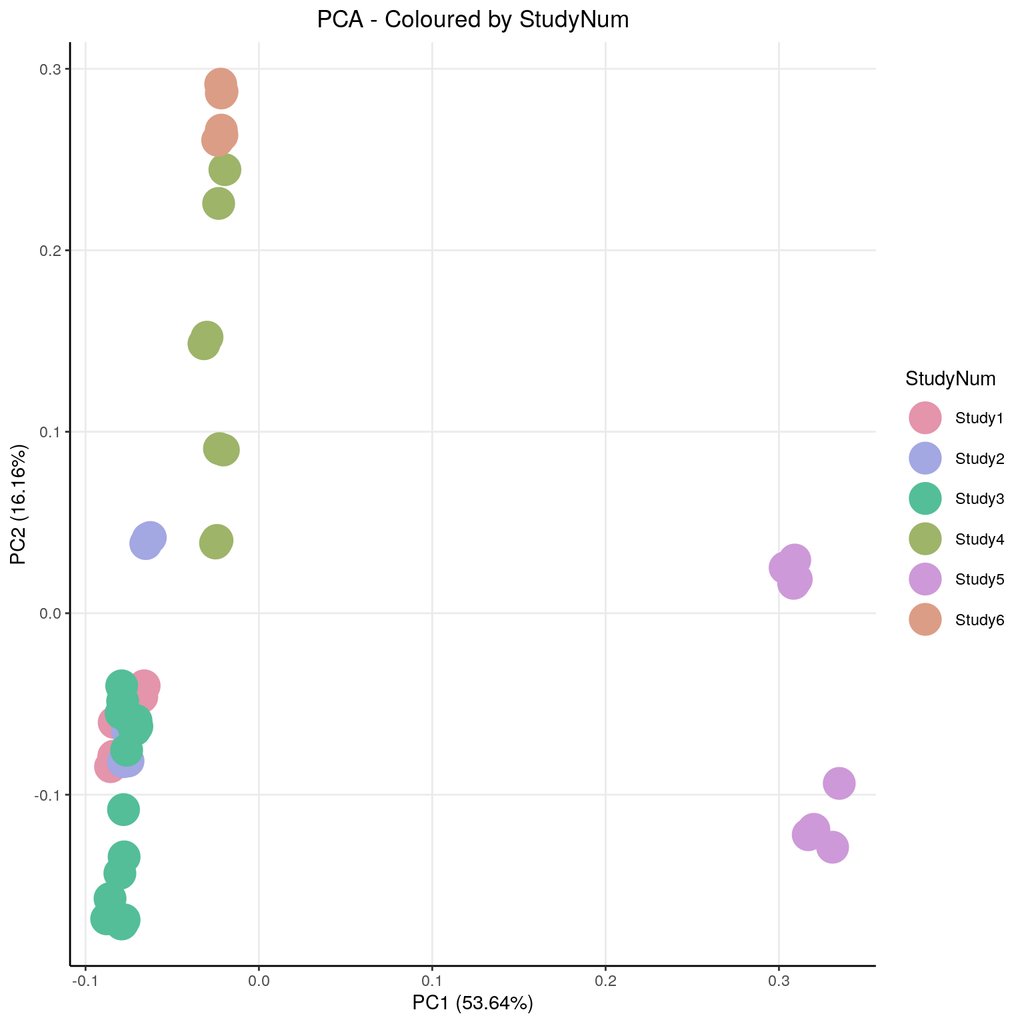

```r
p_study
```

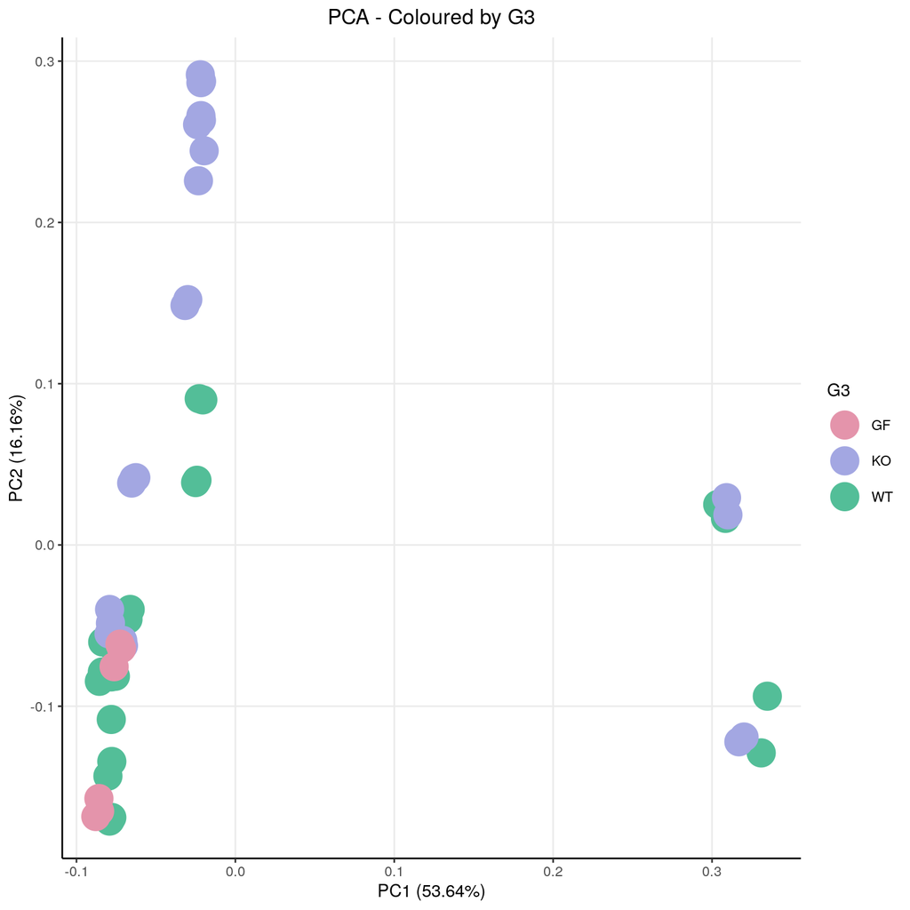

```r
p_g3
```

```r
#in case you want to see most important genes for PCA yourself
contribs1 <- pca_res$rotation[,1]
contribs2 <- pca_res$rotation[,2]

#These are the biggest contributors to the PCA1 (right side)
(pos1genes <- sort(contribs1, decreasing=T)[1:10])
```

```
##      UCHL1       CD24    ALDH1A1     IGFBP3     AKR1C2    CHCHD10   PPP1R14A
## 0.05555770 0.05024173 0.04925481 0.04884217 0.04872499 0.04778164 0.04612179
##       QPCT       DKK1      NETO2
## 0.04464417 0.04425069 0.04403174
```

```r
#These are the biggest contributors to the PCA1 (left side)
(neg1genes <- sort(contribs1, decreasing=F)[1:10])
```

```
##      MAGEA4     EPB41L3       LAMA1         NDN        MT1E        H1-1
## -0.05284954 -0.04845686 -0.04718375 -0.04690883 -0.04681979 -0.04560684
##      MAGEA1        MMP2     MAGEA12      HAPLN1
## -0.04554422 -0.04462558 -0.04452851 -0.04388095
```

```r
#These are the biggest contributors to the PCA2 (up side)
(pos2genes <- sort(contribs2, decreasing=T)[1:10])
```

```
##     CCL4L2       CCL4  ICAM4-AS1     CXCL10      IFNL1      ICAM1    SLC17A9
## 0.07714523 0.07529932 0.06649993 0.06636159 0.06400978 0.06380167 0.06366112
##    MAGEA10       XAF1       PRAL
## 0.06348145 0.06300845 0.06222532
```

```r
#These are the biggest contributors to the PCA2 (down side)
(neg2genes <- sort(contribs2, decreasing=F)[1:10])
```

```
##        RMRP       RPPH1     RN7SL4P       RN7SK         7SK     SCARNA7
## -0.08730559 -0.08264955 -0.07588927 -0.07440439 -0.07430223 -0.07231440
##    SCARNA10        H1-1      RNU4-1     RNU5E-1
## -0.06955450 -0.06710728 -0.06690619 -0.06671143
```

As one can observe from the PCAs, our PC1 is mostly explained by cell type.

Now, in my opinion, cell type, as well as the other variables, are not really relevant in this case. Therefore, I will treat them as “batch-effect”, and will remove them. This way, we can compare samples from different cells, as they were the same.

## Batch Effect Correction

```r
batch_cols <- c("Cell", "Study", "G3", "Stress")
metadata_cols <- c("SG")
mmbatch <- model.matrix(reformulate(paste0("~0 + ",paste0( batch_cols,collapse = " + "))), data=metadata)
mmkeep <- model.matrix(reformulate(paste0("~0 + ",paste0( metadata_cols,collapse =  "+" ))), data=metadata)
mm <- cbind(mmkeep,mmbatch)
D0 <- DGEList(2^y$E) #senescence_normcounts
D0 <- calcNormFactors(D0)
y <- voom(D0, mm, plot = F)
```

```
## Coefficients not estimable: CellU2-OS StudyStudy5
```

```r
fit <- lmFit(y, mm)
```

```
## Coefficients not estimable: CellU2-OS StudyStudy5
```

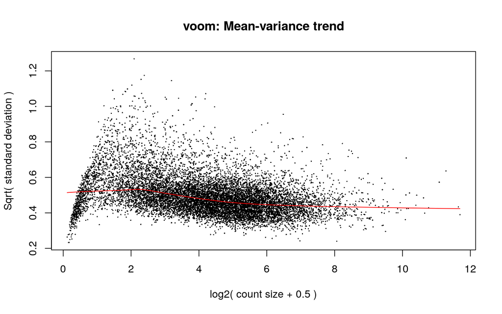

```r
beta <- fit$coefficients[,-(1:ncol(mmkeep)),drop=FALSE]
#beta <- fit$coefficients
beta[is.na(beta)] <- 0
corrcounts_v1 <- as.matrix(y$E) - beta %*% t(mmbatch)
offset <- apply(corrcounts_v1,1,min) - apply(y$E,1,min)
corrcounts_v1 <- as.data.frame(corrcounts_v1-offset)
corrcounts_v1 <- 2^corrcounts_v1


mm <- model.matrix(~0+SG, metadata)

y <- voom(corrcounts_v1, mm, plot = T)
```

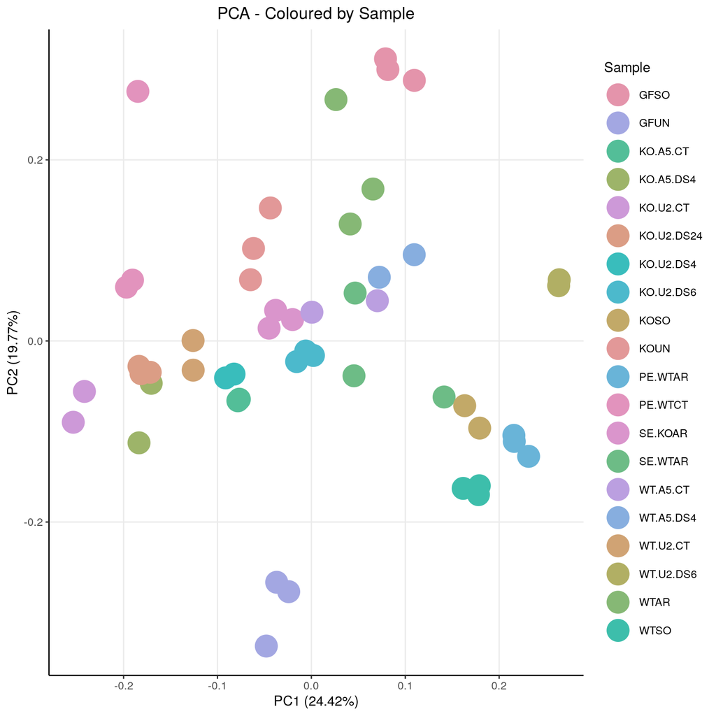

```r
#This prepares my data for the PCA
dfforpca <- y$E
dfforpca <- t(dfforpca)
dfforpca <- as.data.frame(dfforpca) # needs to be a data.frame
dfforpca <- apply(dfforpca, 2, as.numeric) # Ensure numeric
dfforpca <- as.data.frame(dfforpca) # still needs to be a data.frame

# Add metadata, which we will then use to plot
dfforpca$Sample <- Sample_names
dfforpca$StressType <- metadata$Stress
dfforpca$CellType <- metadata$Cell
dfforpca$SGPres <- metadata$SG
dfforpca$StudyNum <- metadata$Study
dfforpca$G3 <- metadata$G3

# PCA computation itself. I do one PCA for each variable I want to see.
pca_res <- prcomp(dfforpca[, 1:(ncol(dfforpca)-6)], scale = FALSE)
p_sample<- autoplot(pca_res, data = dfforpca, x = 1, y = 2, colour = "Sample", size = 8) +
  theme_bw() +
  scale_colour_manual(name = "Sample", values = custom_palette) +
  ggtitle("PCA - Coloured by Sample") +
  theme(plot.title = element_text(hjust = 0.5),
        axis.line = element_line(colour = "black"),
        panel.grid.minor = element_blank(),
        panel.border = element_blank(),
        panel.background = element_blank())

p_stress<- autoplot(pca_res, data = dfforpca, x = 1, y = 2, colour = "StressType", size = 8) +
  theme_bw() +
  scale_colour_manual(name = "StressType", values = custom_palette) +
  ggtitle("PCA - Coloured by StressType") +
  theme(plot.title = element_text(hjust = 0.5),
        axis.line = element_line(colour = "black"),
        panel.grid.minor = element_blank(),
        panel.border = element_blank(),
        panel.background = element_blank())

p_sg <- autoplot(pca_res, data = dfforpca, x = 1, y = 2, colour = "SGPres", size = 8) +
  theme_bw() +
  scale_colour_manual(name = "SGPres", values = custom_palette) +
  ggtitle("PCA - Coloured by SGPres") +
  theme(plot.title = element_text(hjust = 0.5),
        axis.line = element_line(colour = "black"),
        panel.grid.minor = element_blank(),
        panel.border = element_blank(),
        panel.background = element_blank())

p_cell <- autoplot(pca_res, data = dfforpca, x = 1, y = 2, colour = "CellType", size = 8) +
  theme_bw() +
  scale_colour_manual(name = "CellType", values = custom_palette) +
  ggtitle("PCA - Coloured by CellType") +
  theme(plot.title = element_text(hjust = 0.5),
        axis.line = element_line(colour = "black"),
        panel.grid.minor = element_blank(),
        panel.border = element_blank(),
        panel.background = element_blank())

p_study <- autoplot(pca_res, data = dfforpca, x = 1, y = 2, colour = "StudyNum", size = 8) +
  theme_bw() +
  scale_colour_manual(name = "StudyNum", values = custom_palette) +
  ggtitle("PCA - Coloured by StudyNum") +
  theme(plot.title = element_text(hjust = 0.5),
        axis.line = element_line(colour = "black"),
        panel.grid.minor = element_blank(),
        panel.border = element_blank(),
        panel.background = element_blank())

p_g3 <- autoplot(pca_res, data = dfforpca, x = 1, y = 2, colour = "G3", size = 8) +
  theme_bw() +
  scale_colour_manual(name = "G3", values = custom_palette) +
  ggtitle("PCA - Coloured by G3") +
  theme(plot.title = element_text(hjust = 0.5),
        axis.line = element_line(colour = "black"),
        panel.grid.minor = element_blank(),
        panel.border = element_blank(),
        panel.background = element_blank())

p_sample
```

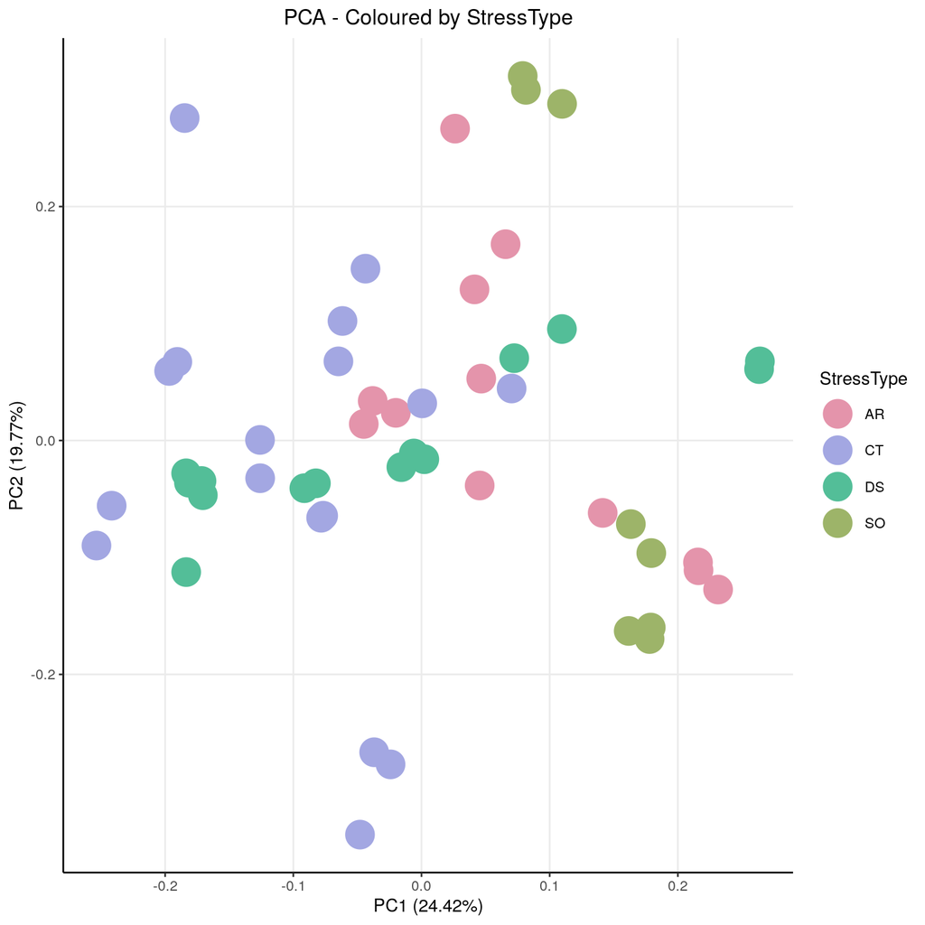

```r
p_stress
```

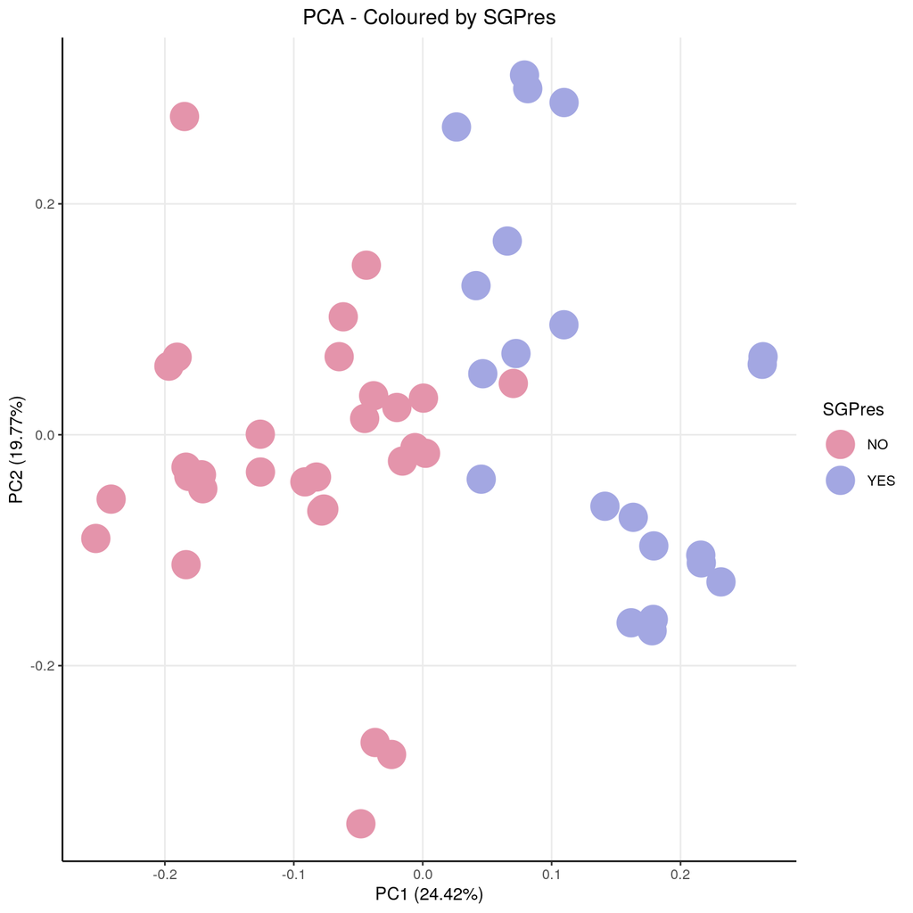

```r
p_sg
```

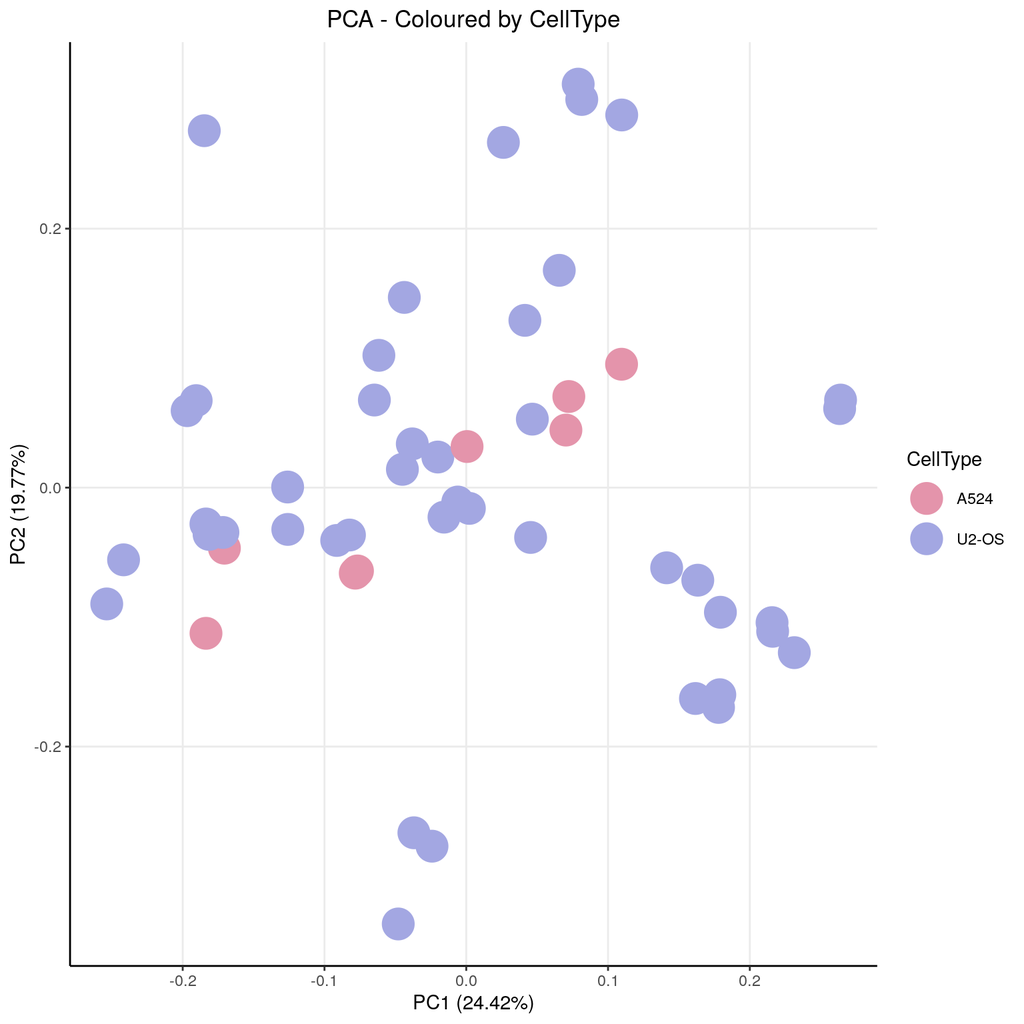

```r
p_cell
```

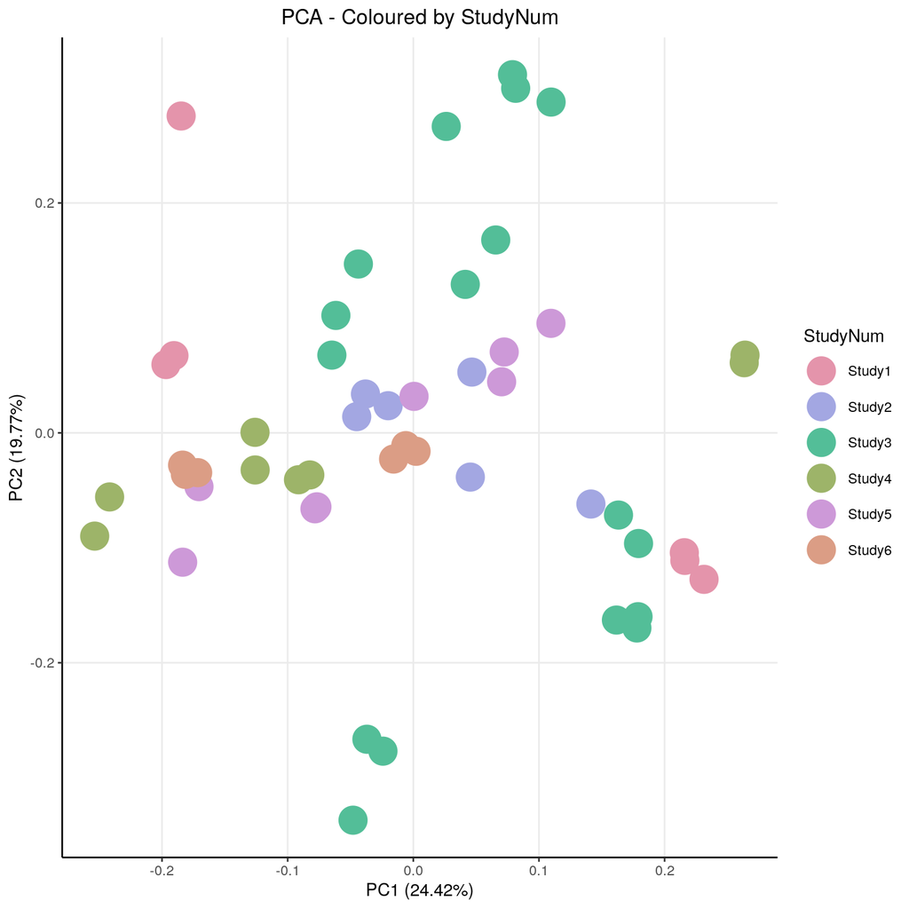

```r
p_study
```

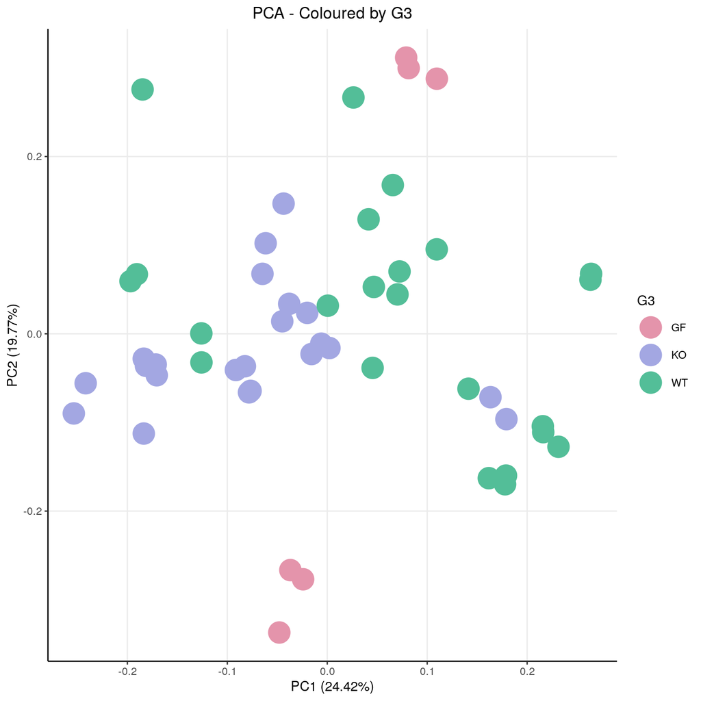

```r
p_g3
```

```r
#in case you want to see most important genes for PCA yourself
contribs1 <- pca_res$rotation[,1]
contribs2 <- pca_res$rotation[,2]

#These are the biggest contributors to the PCA1 (right side)
(pos1genes <- sort(contribs1, decreasing=T)[1:10])
```

```
##     ZNF283     RN7SL3      PPME1    ADAMTS1       DIO2    COL26A1      TAGLN
## 0.03544295 0.03025489 0.02965810 0.02786280 0.02688008 0.02554819 0.02510966
##      SHOC1       ALPL     DCBLD1
## 0.02326264 0.02322950 0.02194188
```

```r
#These are the biggest contributors to the PCA1 (left side)
(neg1genes <- sort(contribs1, decreasing=F)[1:10])
```

```
##       IFIT2       IFIT3        OASL         FOS       CXCL8      SEMA3A
## -0.10775572 -0.09616042 -0.09459577 -0.07362873 -0.07133314 -0.06884949
##       IFI44        CCL3       CCL20       IFNL1
## -0.06813045 -0.06758157 -0.06716590 -0.06166831
```

```r
#These are the biggest contributors to the PCA2 (up side)
(pos2genes <- sort(contribs2, decreasing=T)[1:10])
```

```
##      MXRA8       KLK6     MAGEC1       CCL2      TNNC1     CXCL14      CRYAB
## 0.05646934 0.05103233 0.04988028 0.04750861 0.04668060 0.04623511 0.04252552
##       DYSF     HAPLN1        LUM
## 0.04202896 0.04194838 0.04029741
```

```r
#These are the biggest contributors to the PCA2 (down side)
(neg2genes <- sort(contribs2, decreasing=F)[1:10])
```

```
##      RNU4-2      RNU4-1       H2AC8     RNU5B-1     RNU5E-1     RNU2-2P
## -0.07074002 -0.06685494 -0.06360489 -0.06148932 -0.06120772 -0.06080491
##       H2BC8     RNU5A-1       RNU12       TFPI2
## -0.05649828 -0.05443885 -0.04410292 -0.04181380
```

## Linear Modelling

Finally, we move on to differential gene expression! In this chunk, I define the linear model I will actually use for my analyses.

```r
fitted <- lmFit(y$E, mm)

head(coef(fitted))
```

```
##              SGNO    SGYES
## 7SK      4.240508 3.638618
## A1BG     2.584345 2.652682
## A1BG-AS1 3.303120 3.129870
## A2M      1.628742 1.736526
## AAAS     6.667465 6.586169
## AACS     6.100589 6.084655
```

```r
contr <- makeContrasts(SGYES - SGNO , levels = colnames(coef(fitted)))

tmp_contr <- contrasts.fit(fitted, contr)

tmp <- eBayes(tmp_contr)
top.table <- topTable(tmp, sort.by = "logFC", n=Inf)
DEGenes <- top.table
ndegs=40
```

## SG vs Non-SG

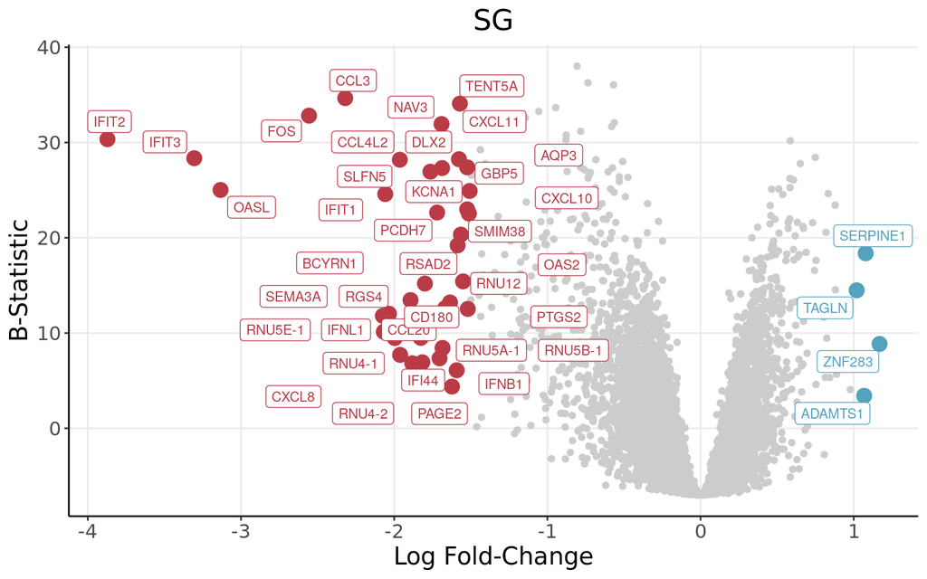

```r
upmarkers <- as.data.frame(DEGenes[DEGenes$logFC>1 & DEGenes$adj.P.Val<0.05,] )

downmarkers <- as.data.frame(DEGenes[DEGenes$logFC< -1.5 & DEGenes$adj.P.Val<0.05,] )

ggplot(data=DEGenes,
                 aes(x=logFC,
                     y=  B)) +
  geom_point(color="#CCCCCC")+
  theme_bw() + ylab("B-Statistic")+xlab("Log Fold-Change")+
  theme(axis.line = element_line(colour = "black"),
        panel.grid.minor = element_blank(),
        panel.border = element_blank(),
        panel.background = element_blank()) +
  ggtitle("SG")+
  theme(plot.title = element_text(hjust = 0.5), plot.subtitle = element_text(hjust = 0.5)) +geom_point(data=upmarkers, aes(x=logFC, y=  B), color="#53A2BE",size=4)+
  geom_point(data=downmarkers, aes(x=logFC, y=  B), color="#BA3B46",size=4)+
  geom_label_repel(upmarkers[1:ndegs,] , mapping=aes(label=row.names(upmarkers)[1:ndegs]),size=3,point.padding=-0.5, color="#53A2BE",max.overlaps = 20)+
  geom_label_repel(downmarkers[1:ndegs,] , mapping=aes(label=row.names(downmarkers)[1:ndegs]),size=3,point.padding=-0.5, color="#BA3B46",max.overlaps = 20)+
  theme(text=element_text(size=15,  family="Arial MS"))
```

```r
write.table(DEGenes, "~/Projects/StressGranules/SGPAPER/RealSGs/MergedWCSig.txt", row.names = T, col.names = T)
```

From the volcano, we can see downregulation of FOS and IFIT transcripts, which are important in inflammation and stress signalling.

## GSEA Enrichment

Now that we have our genes of interest, it would also be interesting to see what are the **altered pathways** between enriched and depleted RNAs from the stress granules. Therefore, lets perform a *Gene Set Enrichment Analysis*

```r
#for all genes
DEGenes <- DEGenes[order(DEGenes[,3]),]
gseatool <- DEGenes[,3]
gseatool <- as.data.frame(gseatool)
colnames(gseatool)[1] <- "t"
gseatool[,2] <- row.names(DEGenes)
colnames(gseatool)[2] <- "Symbol"
gseatool <- gseatool[,c(2,1)]

#for only the genes without the contamination


vectorranks <- gseatool$t
names(vectorranks) <- gseatool$Symbol


#to load our pathways
hallmarks.gs <- msigdbr(species = "Homo sapiens", collection =  "H")

hallmarks.gsets <- hallmarks.gs %>% split(x = .$gene_symbol, f = .$gs_name)

for (set in names(hallmarks.gsets)){
  hallmarks.gsets[[set]] <- toupper(hallmarks.gsets[[set]])
}

hallmarks.res <- fgsea(pathways = hallmarks.gsets,
                       stats = vectorranks)
```

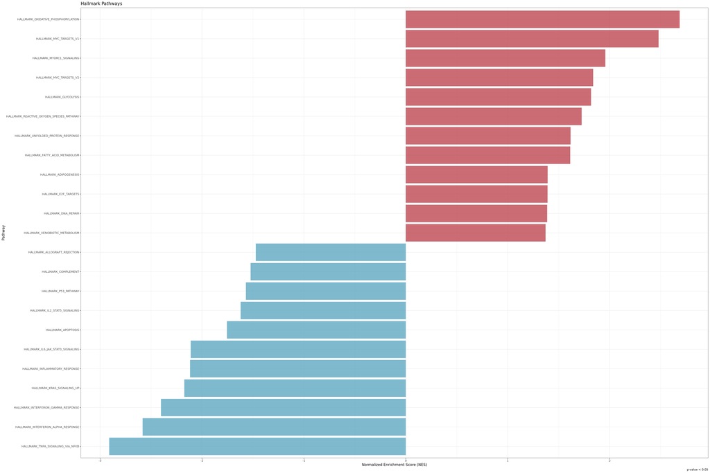

```r
hallmarks.res.tidy <- hallmarks.res %>%
  as_tibble() %>%
  arrange(desc(NES))

hallmarks.res.tidy %>%
  dplyr::select(-leadingEdge, -ES) %>%
  arrange(padj)

hallmark.sg.t <- hallmarks.res.tidy[,c(1,6)]
hallmark.sg.t <- as.data.frame(hallmark.sg.t)

#this small part is generic
thresh <- 0.05

#this one is no longer generic
data_to_plot <- hallmarks.res.tidy %>% filter(padj < thresh)

statvec <- c()
for (i in 1:nrow(data_to_plot)){
  if (data_to_plot[i,6] > 0){
    status <- "Upregulated"
  }
 else {
   status <- "Downregulated"
 }
statvec <- c(statvec, status)
}

data_to_plot$Status <- statvec

##-----HALMARK-----
gsea_plot_hall <- ggplot(data_to_plot, aes(reorder(pathway, NES), NES)) +
  geom_col(aes(fill= Status), alpha=0.75) + scale_fill_manual(values = c("#53A2BE","#BA3B46"), name = "Regulation Status", labels = c("Downregulated", "Upregulated"), breaks = c("Downregulated", "Upregulated")) +
  coord_flip() +
  labs(x="Pathway", y="Normalized Enrichment Score (NES)",
       title= "Hallmark Pathways",
       caption = paste0("p-value < ", thresh)) + theme(plot.title = element_text(hjust = 1)) +
  theme_bw() + theme(text=element_text(family = "Quicksand")) + theme(legend.position = "none")

gsea_plot_hall
```

We have a downregulation in several inflammation pathways.

[^1]: Disease Transcriptomics Group, Gulbenkian Institute of Molecular Medicine